# Air Quality and Asthma in the United States: A State-Level Analysis

Morde Bernstein, Marley McGehee, Kimberly McNeil

5/01/2026

## Introduction

Our first dataset is focused on adult asthma prevalence by state in 2020. We obtained this dataset from the CDC website at the [2020 Archived State or Territory Asthma Data](https://www.cdc.gov/asthma/archivedata/2020/2020_archived_states_territory.html) page. The data has a sample size of 53, including the 50 states, D.C., and 2 territories (Guam and Puerto Rico), and includes both numbers with current asthma and percent with current asthma variables.

Our second dataset is about air pollution particulate matter by state, also in 2020. We obtained this data from the National Institute on Minority Health and Health Disparities at the Physical Environment - Air Pollution page. The sample size is 52 (all 50 states, D.C., and the U.S as a whole, not including Puerto Rico for being listed as NA and Guam for being missing entirely), and the data includes air particulates in micrograms per cubic meter (PM2.5). This is a measure of air pollution which looks at the average number of particulates in the air daily.

## Data Import

```r
# Dataset 1 Import
asthma <- read_csv("asthma_prevalence - Sheet1.csv",show_col_types = FALSE)

# Initialize cleaning the column names (and giving names to the unnamed)
asthma <- janitor::clean_names(asthma)

# Make the janitor's work clearer
asthma <- asthma %>%
  rename(
    state = state_or_territory,
    asthma_number = number_with_current_asthma,
    asthma_percent = percent_with_current_asthma_se) %>%
   mutate(asthma_percent = parse_number(asthma_percent))

# Dataset 2 Import

pollution <- read_csv("HDPulse_data_export (1).csv",
    skip = 5,show_col_types = FALSE)
# Initialize cleaning the column names (and giving names to the unnamed)
pollution <- janitor::clean_names(pollution)


# Make the janitor's work clearer
pollution <- pollution %>%
  rename(state = state,
    fips = fips,
    pollution = micrograms_per_cubic_meter_pm2_5_1)
```

Both of our datasets were CSV files, so we used read_csv() to open them. For the air pollution particulate matter, we skipped the first five rows because they contained metadata rather than observations. Then, we standardized column names using janitor::clean_names(), then renamed the variables for clarity. Next, we converted the asthma_percent variable to a numeric format in order to prepare it for numerical operations.

```r
# Join our datasets by state
asthma_air <- asthma %>% left_join(pollution, join_by(state)) %>%
  relocate(fips, .after = state)
```

We then joined our two datasets based on states, as that was the common feature between them. After joining the datasets by state, pollution data was missing for Puerto Rico and Guam. Puerto Rico had a recorded value of NA in the pollution dataset, while Guam was not included in the pollution dataset at all. This resulted in missing values in the merged dataset. Additionally, the pollution dataset included a national-level observation (“United States”), which was excluded during merging since the asthma dataset only contains state-level observations.

The following table explicitly showcases the missing pollution data:

```r
asthma_air %>%
  filter(is.na(pollution)) %>%
  select(state, asthma_percent) %>%
  kable(caption = "Territories and their Asthma Percentages that are Missing from our Merged Dataset")
```

Territories and their Asthma Percentages that are Missing from our Merged Dataset

| state | asthma_percent |
| --- | --- |
| Guam | 5.0 |
| Puerto Rico | 10.4 |

## Exploratory Data Analysis

### Primary Key Variable Discussion

The primary key used to merge the datasets is the state (or territory) name. Both datasets include all 50 U.S. states and D.C., while the asthma dataset also includes the territories of Puerto Rico and Guam.

Some inconsistencies were present between the datasets. For example, the pollution dataset includes an observation for the United States as a whole, which does not have a corresponding entry in the asthma dataset and was thus excluded during the join. Additionally, pollution data for Puerto Rico and Guam were unavailable, leading to missing values for these locations in the merged dataset.

These issues do not significantly affect the analysis, as the focus of this project is on state-level comparisons rather than a national collection.

### Percent with Current Asthma

```r
asthma_air %>%
  summarize(
      Mean = mean(asthma_percent, na.rm = TRUE),
      Median = median(asthma_percent, na.rm = TRUE),
      sd = sd(asthma_percent, na.rm = TRUE),
      Min = min(asthma_percent, na.rm = TRUE),
      Q1 = quantile(asthma_percent, 0.25, na.rm = TRUE),
      Q3 = quantile(asthma_percent, 0.75, na.rm = TRUE),
      Max = max(asthma_percent, na.rm = TRUE),
      n = sum(!is.na(asthma_percent))
  ) %>%
  kable(caption = "Percent of Population with Current Asthma Across States")
```

Percent of Population with Current Asthma Across States

| Mean | Median | sd | Min | Q1 | Q3 | Max | n |
| --- | --- | --- | --- | --- | --- | --- | --- |
| 9.560377 | 9.6 | 1.310364 | 5 | 8.9 | 10.6 | 12.4 | 53 |

The average percent of people with current asthma across states is 9.56%. There is a range in asthma percentages from 5% to 12.4%.

```r
highest_asthma_air <- asthma_air %>%
  select(state, asthma_percent) %>%
  arrange(desc(asthma_percent))

knitr::kable(highest_asthma_air %>%
               head(n = 5),
               caption = "States with Highest Asthma Percentage")
```

States with Highest Asthma Percentage

| state | asthma_percent |
| --- | --- |
| West Virginia | 12.4 |
| Rhode Island | 12.1 |
| Kentucky | 11.5 |
| New Hampshire | 11.5 |
| Michigan | 11.0 |

```r
lowest_asthma_air <- asthma_air %>%
  select(state, asthma_percent) %>%
  arrange(asthma_percent)

knitr::kable(lowest_asthma_air %>%
               head(n = 5),
               caption ="States with Lowest Asthma Percentage")
```

States with Lowest Asthma Percentage

| state | asthma_percent |
| --- | --- |
| Guam | 5.0 |
| Florida | 7.3 |
| Texas | 7.4 |
| Louisiana | 7.8 |
| Nebraska | 7.8 |

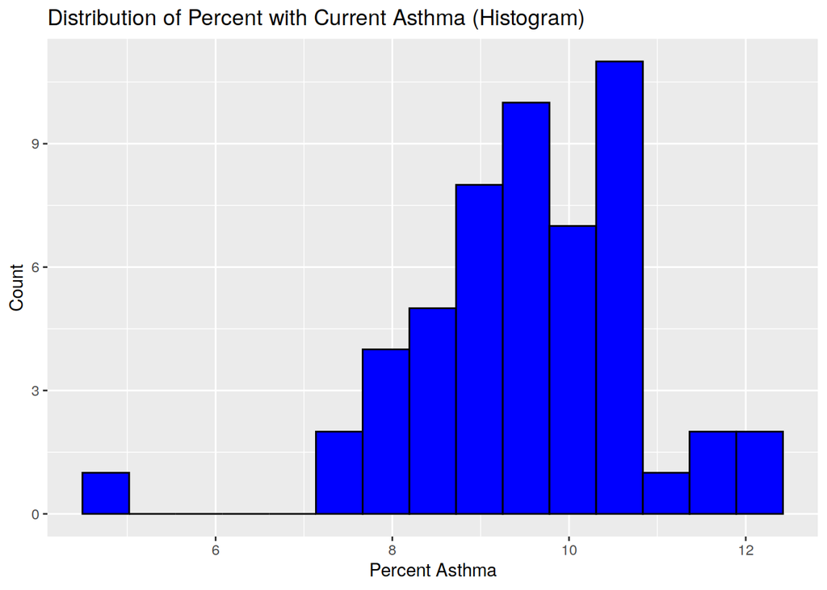

```r
asthma_air %>%
  ggplot(aes(x = asthma_percent)) +
    geom_histogram(bins = 15,
                   fill = "blue",
                   color = "black") +
    labs(title = "Distribution of Percent with Current Asthma (Histogram)",
         x = "Percent Asthma",
         y = "Count")
```

The lowest percentage of asthma overall is in Guam with 5.0%, however for a continental state the lowest percentage is Florida with 7.3%. The highest percent is in West Virginia with 12.4%. From the histogram above, the results show that a large number of states’ asthma percentages fall around 9% to just under 11%. Few states fall below 8% or above 11%..

### Air Pollution

```r
asthma_air %>%
  summarize(
      Mean = mean(pollution, na.rm = TRUE),
      Median = median(pollution, na.rm = TRUE),
      sd = sd(pollution, na.rm = TRUE),
      Min = min(pollution, na.rm = TRUE),
      Q1 = quantile(pollution, 0.25, na.rm = TRUE),
      Q3 = quantile(pollution, 0.75, na.rm = TRUE),
      Max = max(pollution, na.rm = TRUE),
      n = sum(!is.na(pollution))  ) %>%
  kable(caption = "Air Pollution Across States (in micrograms per cubic meter)")
```

Air Pollution Across States (in micrograms per cubic meter)

| Mean | Median | sd | Min | Q1 | Q3 | Max | n |
| --- | --- | --- | --- | --- | --- | --- | --- |
| 7.243137 | 7.3 | 1.666524 | 3.7 | 6 | 8.1 | 12.6 | 51 |

From the above table, the results show that there is an average air pollution across all 50 states of 7.24 micrograms per cubic meter. There is a range of air pollution values from 3.7 to 12.6 micrograms per cubic meter.

```r
lowest_pollution <- asthma_air %>%
  select(state, pollution) %>%
  arrange(pollution)

knitr::kable(lowest_pollution %>%
               head(n = 5),
               caption ="States with Lowest Pollution")
```

States with Lowest Pollution

| state | pollution |
| --- | --- |
| Hawaii | 3.7 |
| Wyoming | 4.8 |
| Alaska | 5.3 |
| Maine | 5.3 |
| New Mexico | 5.4 |

```r
highest_pollution <- asthma_air %>%
  select(state, pollution) %>%
  arrange(desc(pollution))

knitr::kable(highest_pollution %>%
               head(n = 5),
               caption ="States with Highest Pollution")
```

States with Highest Pollution

| state | pollution |
| --- | --- |
| California | 12.6 |
| Oregon | 12.1 |
| Washington | 10.3 |
| Oklahoma | 8.9 |
| Georgia | 8.8 |

The two tables above illustrate that the highest air pollution is in California and the lowest air pollution is in Hawaii.

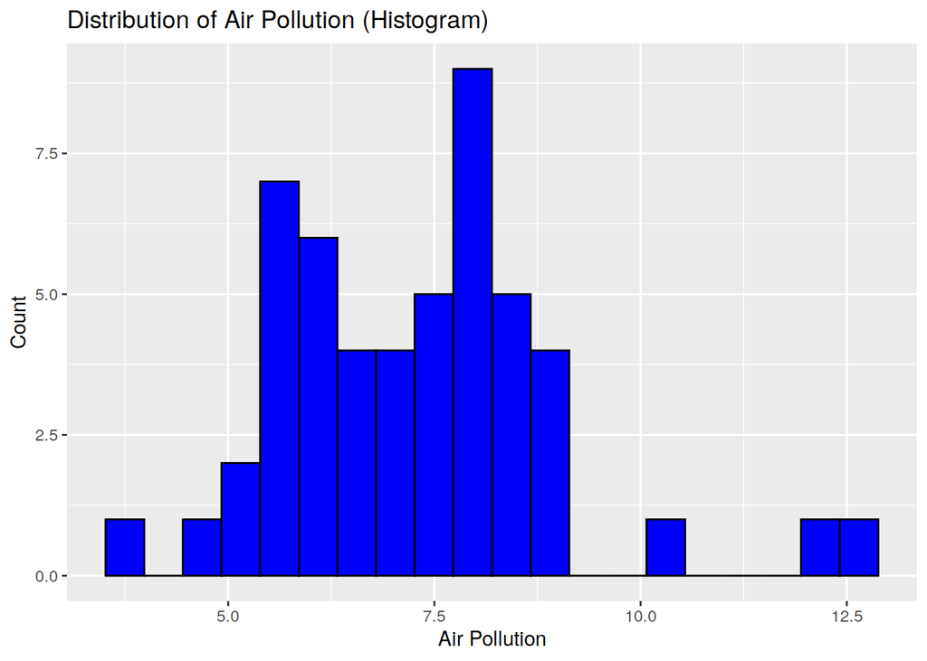

```r
asthma_air %>%
  ggplot(aes(x = pollution)) +
    geom_histogram(bins = 20,
                   fill = "blue",
                   color = "black") +
    labs(title = "Distribution of Air Pollution (Histogram)",
         x = "Air Pollution",
         y = "Count")
```

```r
asthma_air_level <- asthma_air %>%
  mutate (
    pollution_level = cut(pollution, c(-Inf, 5, 9, Inf), c("Low (WHO)", "Low (US)", "High"))
  ) %>%
  count(pollution_level)

knitr::kable(asthma_air_level,
               caption = "States Divided by Air Pollution Levels")
```

States Divided by Air Pollution Levels

| pollution_level | n |
| --- | --- |
| Low (WHO) | 2 |
| Low (US) | 46 |
| High | 3 |
| NA | 2 |

The table above shows a count of air pollution broken apart into different categories based on the micrograms per cubic meter. The WHO standard for healthy air quality levels is under 5 micrograms per cubic meter, while the US standard is under 9 micrograms per cubic meter [(Air Quality Standards)](https://www.iqair.com/us/newsroom/new-epa-annual-pm25-air-quality-standards-expected-save-lives). The two missing values correspond to Puerto Rico and Guam, which do not have available PM2.5 data in the pollution dataset.

### Relationship Analysis

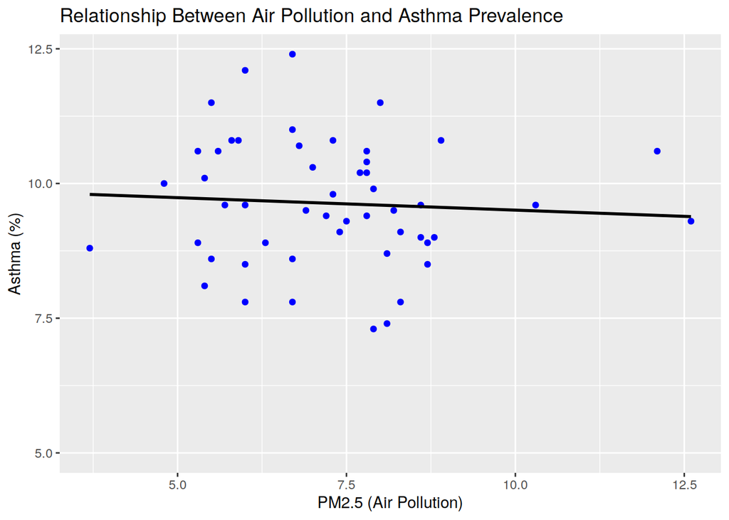

```r
ggplot(asthma_air, aes(x = pollution, y = asthma_percent)) +
  geom_point(color = "blue") +
  geom_smooth(method = "lm", se = FALSE, color = "black") +
  labs(
    title = "Relationship Between Air Pollution and Asthma Prevalence",
    x = "PM2.5 (Air Pollution)",
    y = "Asthma (%)"
  )
```

```r
cor(asthma_air$pollution, asthma_air$asthma_percent, use = "complete.obs")
```

```
## [1] -0.06633903
```

#### Regression Model

We can also create a regression model to see if we can predict asthma prevalence using pollution. The following is our summary that we will analyze in the Research section:

```r
model <- lm(asthma_percent ~ pollution, data = asthma_air)
summary(model)
```

```
##
## Call:
## lm(formula = asthma_percent ~ pollution, data = asthma_air)
##
## Residuals:
##      Min       1Q   Median       3Q      Max
## -2.30295 -0.80009 -0.08907  0.88372  2.74154
##
## Coefficients:
##             Estimate Std. Error t value Pr(>|t|)
## (Intercept)  9.96837    0.73834  13.501   <2e-16 ***
## pollution   -0.04626    0.09939  -0.465    0.644
## ---
## Signif. codes:  0 '***' 0.001 '**' 0.01 '*' 0.05 '.' 0.1 ' ' 1
##
## Residual standard error: 1.171 on 49 degrees of freedom
##   (2 observations deleted due to missingness)
## Multiple R-squared:  0.004401,   Adjusted R-squared:  -0.01592
## F-statistic: 0.2166 on 1 and 49 DF,  p-value: 0.6437
```

## Research

### Research Question

How does air pollution (PM2.5 levels) relate to asthma prevalence across U.S. states?

### Results and Interpretation

#### Scatterplot and Correlation

Because there is no relationship, we can infer that air pollution alone does not explain differences in asthma prevalence across states. Other factors (healthcare access, smoking, urbanization, environmental differences) may also play a role and may be stronger than air pollution.

#### Regression Model

To further examine the relationship between air pollution and asthma prevalence, we fitted a linear regression model with asthma percentage as the response variable and PM2.5 levels as the predictor.

The model found a very small negative relationship between pollution and asthma prevalence (with slope = -0.046), suggesting that higher pollution is associated with a very slight decrease in asthma rates. However, this relationship was not statistically significant (p = 0.644), indicating that there is no meaningful evidence of an association between the two variables.

Additionally, the model’s R^2 value was around 0.004, indicating that air pollution explains less than 1% of the variation in asthma prevalence across states. This tells us that other factors (like the ones mentioned with the scatterplot) likely play a much larger role.

Again, note that two observations (Puerto Rico and Guam) were excluded from the model due to missing pollution data.

### Limitations

Some limitations of this analysis include the following: the data are from a single year (2020); state-level averages may hide local variation; pollution data are unavailable for Puerto Rico and Guam, slightly reducing the completeness of the dataset; and potential differences in data collection methods between sources may introduce inconsistencies.

## Conclusion

This analysis examined whether air pollution (PM2.5) is associated with asthma prevalence across U.S. states. Through univariate and bivariate analysis, we found that there were differences in air pollution levels and asthma levels across states; however, both the correlation coefficient and regression model suggest that air pollution does not significantly explain differences in asthma prevalence at the state level.

These findings suggest that asthma prevalence is likely influenced more strongly by other factors, such as healthcare access, socioeconomic conditions, or localized environmental exposures. Additionally, the use of state-level averages may obscure smaller-scale relationships that exist within states.

One limitation to this research is that the data was taken during a single year (2020), which may not reflect longer-term trends, especially given the unusual conditions during the COVID-19 pandemic. Future research could explore multi-year data or more localized datasets to better understand the relationship between air quality and asthma. Additionally, the asthma dataset is on adult prevalence. It could be interesting to see if children are more susceptible, as well as if air pollution could increase the severity of asthma symptoms.